None

# Table of Contents

return home

# Motorcycle and Bicycle Potential Energy

[Alexander Brown, Ph.D](https://sites.lafayette.edu/brownaa)

## Introduction and Approach

In the LaGrangian derivation of the fourth order Whipple-Style model of motorcycle and bicycle dynamics, it is necessary to bookkeep the potential energy stored in the model's rigid bodies. For the motorcycle model with the Whipple assumptions, this simply means keeping track of gravitational potential energy for the front and rear frames using the familiar form $V = mg\Delta h$ where $h$ is a change in distance in the direction of the gravitational field. We will use the coordinate system and variables introduced in the fourth order model derivation, which are reproduced below.

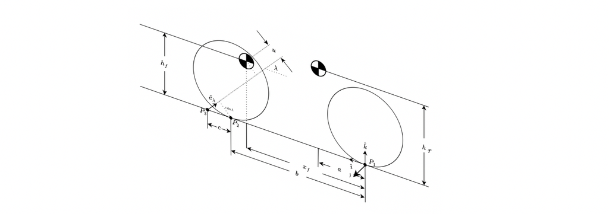

**Figure 1. Coordinates and dimensions**

In the following sections, we will treat the front and rear frame potentially separately, and then write the total potential energy $V = V_r + V_f$.

## Rear Frame Potential Energy

Note that we will *not* linearize this equation for small roll angles $\phi$ just yet, because the LaGrangian formulation requires us to take the potential energy's derivative. If we linearize too early, would find that the potential energy has no effect on the model since $\cos\phi \approx 1$ for small $\phi$, and would disappear when we took the derivative $\frac{\partial V}{\partial \phi}$.

To find the front frame's energy we will look at an expanded version of Figure 1 above, with a few more lengths and intersection points labeled.

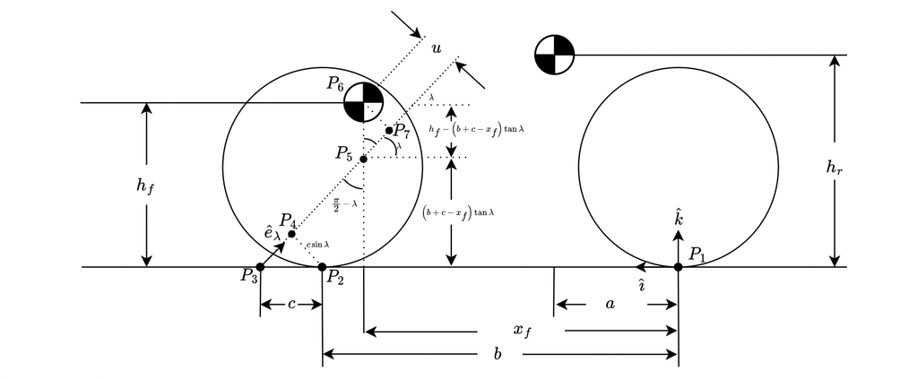

**Figure 2. Expanded coordinates and dimensions**

The front frame mass center's height depends on the bike's roll angle, much like the rear frame's, but it also depends on the steer angle $\delta$ since the steering axis has both a $\hat{\imath}$ and a $\hat{k}$ component.

To find the height of the front frame above the ground in the global $z$ direction, we can break up the height into two portions: one will represent the height of a common point on both the front and rear frames that only rolls, and then a second part that both rolls and steers with the front frame. Point $P_5$ is on the steer axis, so it is a point common to both bodes. Therefore, looking at Figure 2, we can write:

\begin{equation} z_f = z_{P5} + z_{P6-P5} \end{equation}

Where $z_{P6-P5}$ is the vertical distance between $P_6$ and $P_5$, assumed positive when $P_6>P_5$.

The height $z_{P5}$ depends only on roll. From Figure 2 above, we find:

\begin{equation} z_{P5} = \cos\phi\left(b+c-x_f\right)\tan\lambda \end{equation}

Then, the height of $P_6$ above $P_5$ depends on the "effective front frame roll," which is introduced in detail as Eqn 6 in the tire force torques notebook as $\phi_f = \phi - \delta\cos\lambda$. Using the perpendicular distance $u= \left(h_f-\left(b+c-x_f\right)\tan\lambda\right)\sin\left(\frac{\pi}{2}-\lambda\right)$ developed in the D'Alembert Torques notebook, along with the triangle $P_5P_6P_7$ in Figure 2, we find:

\begin{equation} z_{P6-P5} = \cos\phi_f \frac{u}{\cos\lambda} \end{equation}